# STAT656: Homework 1

Analyzing Airline Flight Delays.

# Introduction and Data

We will be analyzing airline flight delays. Note that this Rmd file will not knit in its current form. It is necessary to complete some of the below items for it to knit successfully.

## Download

The first step in this assignment will be downloading the flight data from the [Bureau of Transportation Statistics](https://www.transtats.bts.gov/DL_SelectFields.asp?Table_ID=236&DB_Short_Name=On-Time)

Here are some instructions:

- Set “Filter Year” to 2019
- Set “Filter Period” to January
- Select the following fields:
  - Month
  - DayofMonth
  - DayofWeek
  - FlightDate
  - Reporting_Airline
  - DOT_ID_Reporting_Airline
  - OriginAirportID
  - OriginCityMarketID
  - Origin
  - OriginCityName
  - OriginState
  - DestAirportID
  - DestCityMarketID
  - Dest
  - DestCityName
  - DestState
  - DepDelay
  - DepDel15
  - ArrDelay
  - ArrDel15
  - Cancelled
  - CancellationCode
- Click “Download”
- Change the “Filter Period” to February and Click “Download”
- Change the “Filter Period” to March and Click “Download”
- …
- Change the “Filter Period” to December and Click “Download”

## Uncompress and rename

Now, go to wherever your operating system defaults to downloading, more than likely your ‘download’ directory. There will be 12 files .zip files there. Uncompress each of these files and rename the resulting .csv file a new name corresponding to the order in which they were downloaded (and hence the month of the year). Using ‘snake-case’ would probably work well here

- 2019_01.csv
- 2019_02.csv
- …
- 2019_12.csv

## Move the files

Make a subdirectory of your R working directory (the working directory is where your .Rmd file is located) called “database”. Now, we want to run the following code to generate an R object that is a single flat file containing all the flights for 2019.

## Let’s load in some packages.

```r
if(!require(tidyverse)){install.packages('tidyverse');require(tidyverse)}
```

# Problem 0 (20 pts)

Now, we want to take the data and make a data set. First, let’s get the file names from the database directory

```r
paths = dir("database",pattern="2019_",full.names=TRUE)
print(paths)
```

```
##  [1] "database/flightDelays2019_01.csv" "database/flightDelays2019_02.csv"
##  [3] "database/flightDelays2019_03.csv" "database/flightDelays2019_04.csv"
##  [5] "database/flightDelays2019_05.csv" "database/flightDelays2019_06.csv"
##  [7] "database/flightDelays2019_07.csv" "database/flightDelays2019_08.csv"
##  [9] "database/flightDelays2019_09.csv" "database/flightDelays2019_10.csv"
## [11] "database/flightDelays2019_11.csv" "database/flightDelays2019_12.csv"
```

```r
names(paths) = basename(paths)
```

#### Answer 0.1

What does ‘basename’ do here?

‘basename’ removes the path up to the last path separator and only outputs the filename.If we take, “database/flightdelays2019_01.csv”, it will output “flightDelays2019_01.csv”.

## Creating the data set

This next step can take a few minutes. Let’s time it! Accurately timing code is extremely delicate and controversial because it depends on all the settings on your computer, what other programs you have running, architecture (do you have multiple cores/processors/…) even how long it has been since you rebooted!

But, a simple and useful way is via `proc.time’, which records the computer time of your processor. Let’s read in each .csv file into an R data file that has all of 2019 flights.

(note: we will use ‘cache = TRUE’ so that R studio won’t re-compile this section every time you knit. It will detect any changes to this `chunk’ and re-run if there are any. However, it doesn’t detect if there are changes in another chunk that affect this chunk. For that, we need ‘dependson’. In this case, a change to the directory database would affect ‘df’. So, we want to add ‘dependson’ pointed to that chunk.Note that each dependson chunk must be cached as well)

```r
srt    = proc.time()[3]
dfList = lapply(paths,read.csv)
df     = do.call(rbind,dfList)
end    = proc.time()[3]
cat('total time: ',end-srt)
```

```
## total time:  364.92
```

```r
df$X = NULL #get rid of that empty column
save(df, file="2019flights.Rdata")

totalTime = end - srt #### Answer 0.2 ## Overwrite the totalTime object so that it has the correct elapsed time
```

Answer: This process took 364.92 seconds.

## The data set

Let’s look at some attributes of this data set

```r
dataSetSize = format(object.size(df),units='MiB')
```

#### Answer 0.3

The total size of the flights data set for 2019 is 1387.5 MiB

# Problem 1 (20 pts)

Some of the flights were cancelled and hence never flew. These are recorded via the ‘cancelled’ feature. How many total flights are there in the data set? How many were cancelled?

Additionally, there are some missing values, coded as NA, in the data set. Generally, we would want to impute these missing values. However, we will return to imputation later in the semester. For now, let’s remove the rows (flights) with missing values. Make a new object called flightsNotCancelled that have the flights that were not cancelled and have no missing values. Make sure to use this for the rest of the assignment. Lastly, how many flights do we have remaining in flightsNotCancelled?

```r
totalNum  = nrow(df)
cancelNum =  df %>%
  group_by(CANCELLED) %>%  #### Answer 1.1 ## Insert the correct group_by statement here
  summarise(n = n())

#I just want the integer, not the tibble:
cancelNum = as.integer(cancelNum[2,2])

flightsNotCancelled = df %>%
  filter(!CANCELLED == 1) %>% #### Answer 1.2  Insert the correct filter statement here
  na.omit

flightsNotCancelledCount = nrow(flightsNotCancelled)
```

#### Answer 1.3

The total number of flights is 7422037.

The total number of cancelled flights is 134925.

The total number of flights remaining after removing NAs is 7268232.

# Problem 2 (15 pts)

How many flights were there for each day of the week?

```r
flightsPerDay = flightsNotCancelled %>%
  group_by(DAY_OF_WEEK) %>%
  summarize(total = n())

flightsPerDay
```

```
## # A tibble: 7 x 2
##   DAY_OF_WEEK   total
##         <int>   <int>
## 1           1 1083750
## 2           2 1056064
## 3           3 1048502
## 4           4 1070661
## 5           5 1085374
## 6           6  889963
## 7           7 1033918
```

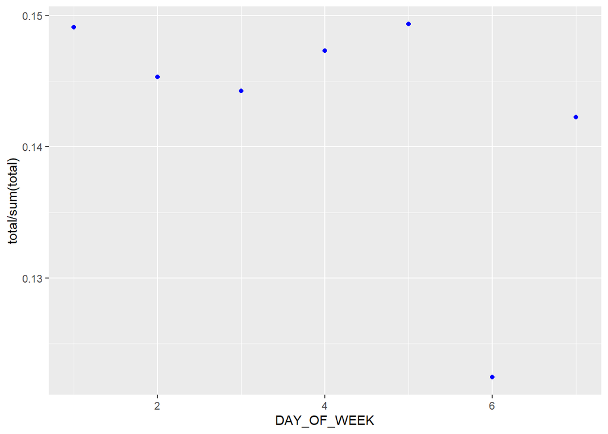

```r
ggplot(data = flightsPerDay) + geom_point(aes(x = DAY_OF_WEEK, y = total/sum(total)),color='blue')
```

```r
#### Answer 2.1 ## Alter this plot so that the points are blue and the plot is of the proportion of flights each day instead of total
```

# Problem 3 (20 pts)

Which month has the greatest proportion of late flights?

```r
props = flightsNotCancelled %>%
  mutate(delayInd = ifelse(DEP_DELAY > 0,1,0)) %>%
  group_by(MONTH) %>% #### Answer 3.1 Fill in the missing part
  summarize(total = n(),success = sum(delayInd),prop = mean(delayInd))

props
```

```
## # A tibble: 12 x 4
##    MONTH  total success  prop
##    <int>  <int>   <dbl> <dbl>
##  1     1 565963  184595 0.326
##  2     2 516314  196330 0.380
##  3     3 618505  206925 0.335
##  4     4 596020  198092 0.332
##  5     5 621339  224148 0.361
##  6     6 620887  255712 0.412
##  7     7 643781  238733 0.371
##  8     8 645351  232621 0.360
##  9     9 594716  161635 0.272
## 10    10 629637  196864 0.313
## 11    11 597107  174636 0.292
## 12    12 618612  238543 0.386
```

```r
greatPropIndex   = which.max(props$prop)
lateFlightsMonth = props$MONTH[greatPropIndex]
```

#### Answer 3.2

The month with the greatest proportion of late flights is 6

# Problem 4 (25 pts)

Which departure and arrival airport combination is associated with the worst median departure delay?

```r
medianDepDelayCombination = flightsNotCancelled  %>%
  select(ORIGIN,DEST,DEP_DELAY) %>% group_by(ORIGIN,DEST) %>%
  summarise_each(list(median=median))
names(medianDepDelayCombination) = cbind("ORIGIN","DEST","medianDepDelay")
combination = medianDepDelayCombination[which.max(medianDepDelayCombination$medianDepDelay),]
combination
```

```
## # A tibble: 1 x 3
## # Groups:   ORIGIN [1]
##   ORIGIN DEST  medianDepDelay
##   <fct>  <fct>          <dbl>
## 1 VPS    SRQ              720
```

#### Answer 4.1

The worst departure/arrival airport combination in terms of median delay is VPS/SRQ